# DAND Final project: Bike sharing

```python
total_rides_weekend = df_2019.query('day_of_the_week == "Sat" | day_of_the_week == "Sun"').user_type.count()
total_rides_weekend
```

```
397392
```

```python
#Average of rides per week (year with 52 weeks)
round(total_rides_week / 52), round(total_rides_weekend / 52)
```

```
(37317.0, 7642.0)
```

```python
#Average of rides per day during the week. And weekends
round(total_rides_week / 52 / 5), round(total_rides_weekend / 52 / 2)
```

```
(7463.0, 3821.0)
```

```python
total_rides = df_2019.user_type.count()
```

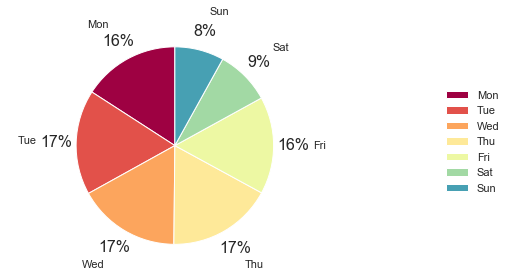

```python
#PIE chart - % of rides per day of week.


fig, ax = plt.subplots()
plt.rcParams['axes.labelcolor']= '#909090'
plt.rcParams['xtick.color'] = '#909090'
plt.rcParams['ytick.color'] = '#909090'
plt.rcParams['font.size']=16
labels = ['Mon', 'Tue', 'Wed', 'Thu', 'Fri', 'Sat', 'Sun']

cmap = plt.get_cmap('Spectral')
colors = [cmap(i) for i in np.linspace(0, 1, 8)]

percentages = [df_2019.query('day_of_the_week == "Mon"').month.count()/total_rides,
               df_2019.query('day_of_the_week == "Tue"').month.count()/total_rides,
               df_2019.query('day_of_the_week == "Wed"').month.count()/total_rides,
               df_2019.query('day_of_the_week == "Thu"').month.count()/total_rides,
               df_2019.query('day_of_the_week == "Fri"').month.count()/total_rides,
               df_2019.query('day_of_the_week == "Sat"').month.count()/total_rides,
               df_2019.query('day_of_the_week == "Sun"').month.count()/total_rides]
explode=(0.,0.,0.,0.,0.,0.,0. )
ax.pie(percentages, explode=explode, labels=labels, colors=colors,
       autopct='%1.0f%%',
       shadow=False, startangle=90,
       pctdistance=1.2,labeldistance=1.4)
ax.axis('equal')
ax.legend(frameon=False, bbox_to_anchor=(1.5,0.8));
```

Pie chart above confirms that.

```python
total_subscriber_rides_week = df_subscriber_week.query('day_of_the_week == "Mon" | day_of_the_week == "Tue" | day_of_the_week == "Wed" | day_of_the_week == "Thu" | day_of_the_week == "Fri"').user_type.count()
total_subscriber_rides_weekend = df_subscriber_weekend.query('day_of_the_week == "Sat" | day_of_the_week == "Sun"').user_type.count()
total_customer_rides_week = df_customer_week.query('day_of_the_week == "Mon" | day_of_the_week == "Tue" | day_of_the_week == "Wed" | day_of_the_week == "Thu" | day_of_the_week == "Fri"').user_type.count()
total_customer_rides_weekend = df_customer_weekend.query('day_of_the_week == "Sat" | day_of_the_week == "Sun"').user_type.count()

total_subscriber_rides_week, total_subscriber_rides_weekend, total_customer_rides_week, total_customer_rides_weekend
```

```
(1619529, 278461, 320941, 118931)
```

Now let's see the split per user type, but on the average per week:

```python
round(total_subscriber_rides_week / 52), round(total_subscriber_rides_weekend / 52), round(total_customer_rides_week / 52), round(total_customer_rides_weekend / 52)
```

```
(31145.0, 5355.0, 6172.0, 2287.0)
```

Let's check below the split per week and weekend, also comparing user types..Are the behaviours the same?

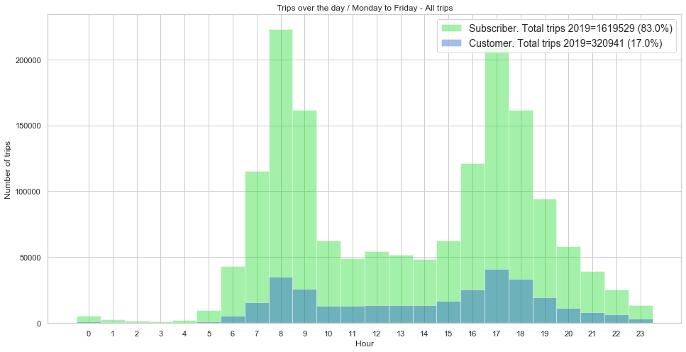

```python
plt.figure(figsize = [16,8])

bin_edges = np.arange(-0.5, 23.5+1, 1)
sns.set(style="whitegrid")

label_subscriber = "Subscriber. Total trips 2019=" + str(df_subscriber_week.user_type.count()) + " (" + str(total_p_subscriber_week) + "%)"
label_customer = "Customer. Total trips 2019=" + str(df_customer_week.user_type.count()) + " (" + str(total_p_customer_week) + "%)"

sns.distplot(df_subscriber_week['hour_of_the_day'], kde = False, color='#19DB26',label=label_subscriber, bins = bin_edges)
sns.distplot(df_customer_week['hour_of_the_day'],kde = False, color='#1C56D6', label=label_customer, bins = bin_edges)

plt.xticks(np.arange(0, 24, 1));
plt.legend(prop={'size': 14})
plt.title('Trips over the day / Monday to Friday - All trips')
plt.xlabel('Hour')
plt.ylabel('Number of trips');
```

During the week, as shown above, Subscribers usage peaks between 8-9am and 5-6pm...coinciding with regular office hours.

Customers also, but the use keep steady also between these intervals : the drop is not as high as the Regular users.

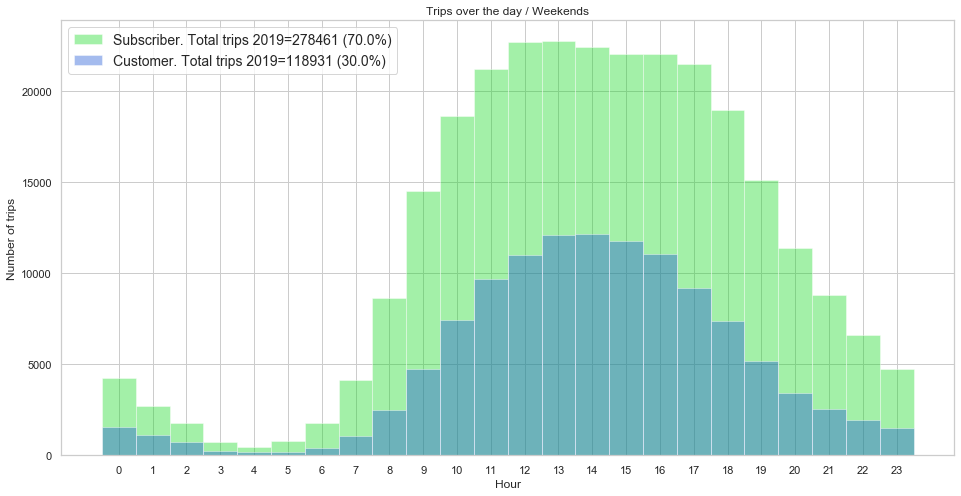

```python
#trips over the day from midnight to 23h - WEEKEND
plt.figure(figsize = [16,8])

bin_edges = np.arange(-0.5, 23.5+1, 1)
sns.set(style="whitegrid")

label_subscriber = "Subscriber. Total trips 2019=" + str(df_subscriber_weekend.user_type.count()) + " (" + str(total_p_subscriber_weekend) + "%)"
label_customer = "Customer. Total trips 2019=" + str(df_customer_weekend.user_type.count()) + " (" + str(total_p_customer_weekend) + "%)"

sns.distplot(df_subscriber_weekend['hour_of_the_day'], kde = False, color='#19DB26', label=label_subscriber, bins = bin_edges)
sns.distplot(df_customer_weekend['hour_of_the_day'],kde = False,color='#1C56D6', label=label_customer, bins = bin_edges)

plt.xticks(np.arange(0, 24, 1));
plt.legend(prop={'size': 14})
plt.title('Trips over the day / Weekends')
plt.xlabel('Hour')
plt.ylabel('Number of trips');
```

It is clear that behaviours are different during the week and weekends.

On the weekends, usage peaks between 11am-5pm to both user types.

It raises the question if the Customers are also people visiting. We can explore more splitting the usave over the months..Let's do it.

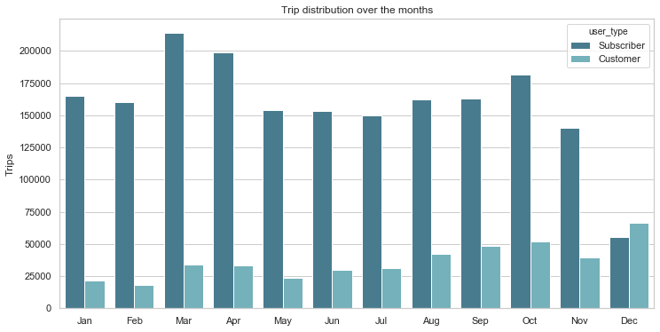

```python
plt.figure(figsize = [12,6])
sns.set(style="whitegrid")

sns.countplot(x="month", hue='user_type', palette = "GnBu_d",
              order=['Jan','Feb','Mar','Apr','May','Jun','Jul','Aug','Sep','Oct','Nov', 'Dec'], data = df_2019);

plt.title('Trip distribution over the months')
plt.ylabel('Trips');
plt.xlabel('');
```

Note that in December the number of Customers increase and reaches its highest point in the year, surpassing the volume of rides from Subscribers. Would that be people visiting the city?

December is also the month where the Subscribers least use the system (55K trips against 220K trips in March). Are they on vacation? Would that mean that Subscribers are workers living in town?

## Stations

```python
df_2019.start_station_id.nunique()
```

```
427
```

There are 427 stations in town

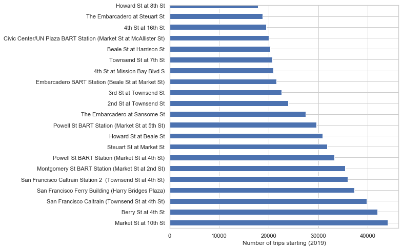

```python
#Stations more used: starting stations
df_2019['start_station_name'].value_counts().plot(kind = 'barh',  figsize=(8,8));
#plt.xlim(29000, 50000);
plt.ylim(top=20);  # adjust the top leaving bottom unchanged
plt.xlabel('Number of trips starting (2019)');
```

The top 20 stations where users initiate a trip

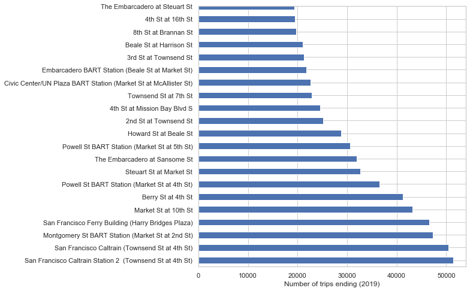

```python
#Stations more used: starting stations
df_2019['end_station_name'].value_counts().plot(kind = 'barh',  figsize=(8,8));
plt.ylim(top=20);
plt.xlabel('Number of trips ending (2019)');
```

The top 20 stations where users end a trip.

Both start and ending stations are centric and common between them. That shows that users are concentrated in downtown.

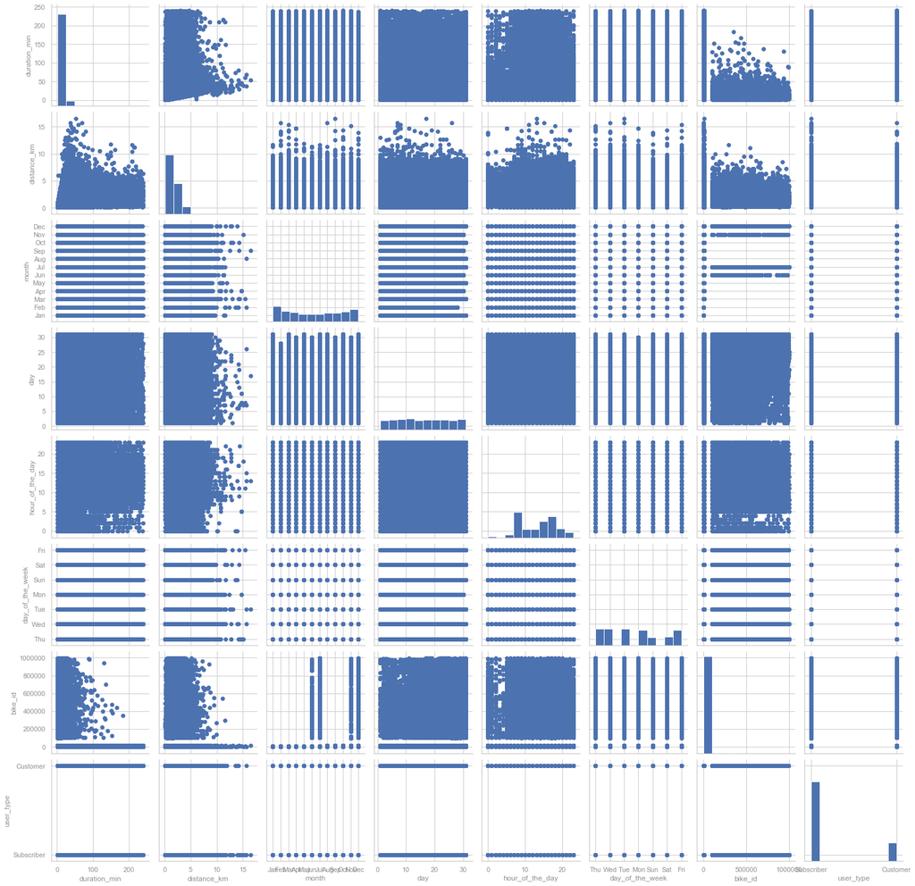

```python
g = sns.PairGrid(data = df_2019, vars = ['duration_min', 'distance_km', 'month' , 'day', 'hour_of_the_day', 'day_of_the_week', 'bike_id', 'user_type' ])

g.map_diag(plt.hist)
g.map_offdiag(plt.scatter);
```

Now (below) I will take a look on the "core" of the rides, removing even more outliers.

```python
df_short = df_2019.copy()
```

```python
df_short.drop(df_short[df_short.distance_km > 7].index, inplace = True)
df_short.drop(df_short[df_short.duration_min > 45].index, inplace = True)
```

```python
df_short.shape, df_2019.shape
```

```
((2305360, 18), (2337862, 18))
```

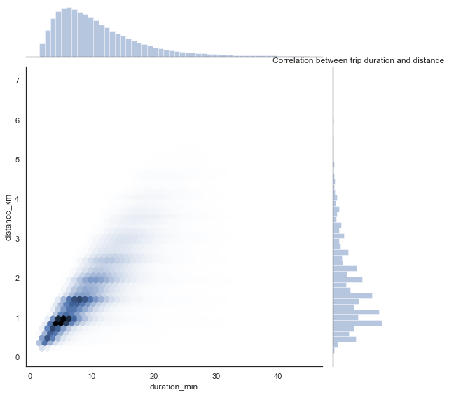

```python
#hexplot to show in dark are the most frequent combinations.
with sns.axes_style("white"):
    sns.jointplot(x=df_short.duration_min, y=df_short.distance_km, kind="hex", height=8);
plt.title('Correlation between trip duration and distance');
```

The most common distances/durations are within 1km and about 5' duration (the dark blue zone). The larger the distance/duration, less rides we have. It shows that the "nature" of the service are rides within that range.

It is an intesting insight to Marketing teams to target people that do errands like that, but can do it faster using the bike sharing service instead of walking and or driving a car.

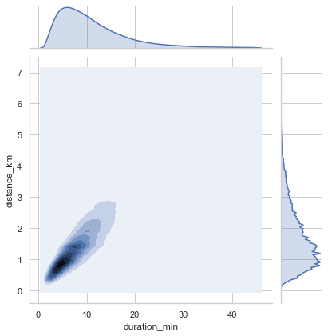

```python
sns.jointplot(x="duration_min", y="distance_km", data=df_short, kind="kde");
```

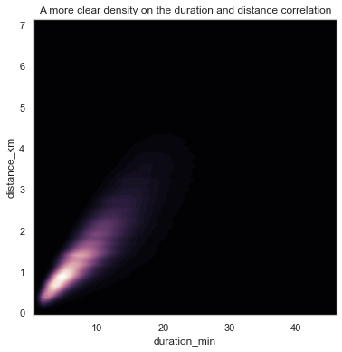

```python
f, ax = plt.subplots(figsize=(8, 8))
cmap = sns.cubehelix_palette(as_cmap=True, dark=0, light=1, reverse=True)
sns.kdeplot(df_short.duration_min, df_short.distance_km, cmap=cmap, n_levels=60, shade=True);
plt.title('A more clear density on the duration and distance correlation');
```

And above we have the same relationship, but with dark colors to reinforce the core of the trips (lighter part of the graphic).

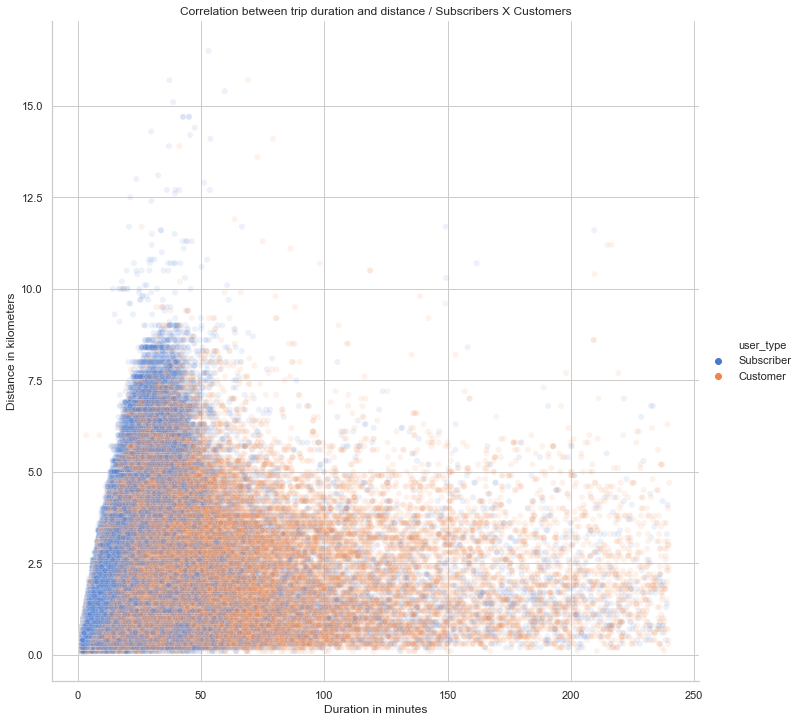

```python
sns.relplot(x="duration_min", y="distance_km", alpha=.1, palette="muted", height=10, data=df_2019, hue="user_type")
plt.title('Correlation between trip duration and distance / Subscribers X Customers')
plt.ylabel('Distance in kilometers')
plt.xlabel('Duration in minutes');
```

Chart above shows us some things:

-that many Subscribers' rides a bit faster than Customers: observe the left part of the chart, that is mainly blue, indicating that Subscribers ride the same distance as Customers, but in a shorter period of time.

-the larger distances are most ridden by Subscribers.

By understanding these differences, marketing campaigns cam be cerated to each group.

```python
df_2019.to_csv('./data/2019_lyft_bike_sharing_rides.csv',
                 index=False, encoding = 'utf-8')
```